# Effect of different attributes on People's Trip Duration

# By Reham ElTagoury

## Investigation Overview

In this investigation, I wanted to know if I can Predict the Duration of the trip from studying diffrent attributes. The main focus was on User type , gender and birth year.

## 1. Duration of the trip

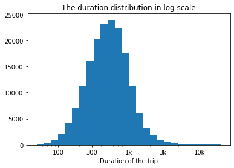

## 2. Location and Distance Covered by the trip

Studying the location I found out that there exist three location and some have the same start and end so this means that the bike didn't move so I had to get the distance to make sure found out that some distances are less than 0.0001 which means that these values are outliers while the rest of the plot is a unimodal distribution with mean of 0.01

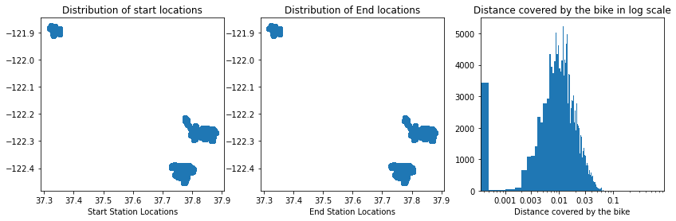

## 3. Day of the week

I studied the days which people perefere to ride their bike found out that thrsday is the most picked day by the people to take their bike so if we want to increase the profit on the days that is not popular like snday and saturday we can make an offer on these days

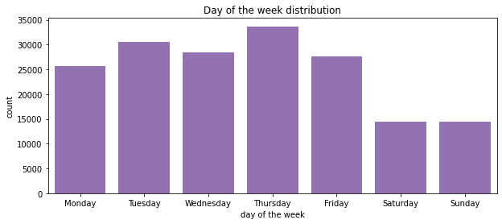

## 4. Duration vs Birth year

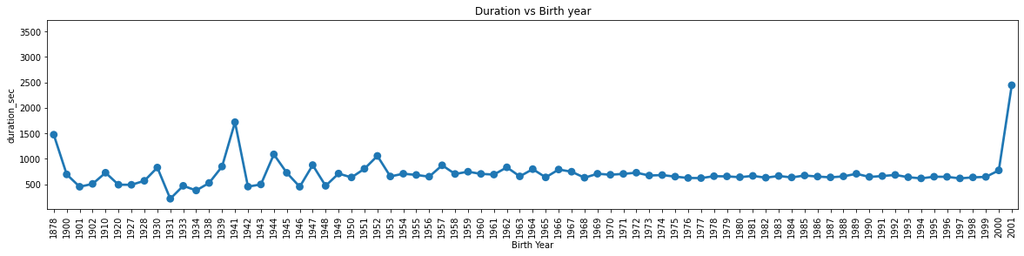

## 5. Duration vs. User Type vs. Member Gender

When comparing these three features together it turns out that the customer tends to make longer trips

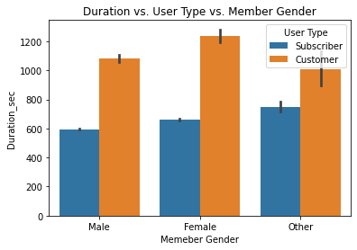